# Categorical Data Analysis Notebook 1 - Binomial and Poisson

**Exercise 1: Football goals** A football player attempts to score 10 goals and has a 0.4 probability of scoring any individual goal.

1. Distribution of X Data frame made with {d}ensity function of the {binom}ial distribution.

```r
data.frame(x=0:10,p=dbinom(x=0:10,size=10,prob=0.4))
```

| x | p |
| --- | --- |
| 0 | 0.0060466176 |
| 1 | 0.0403107840 |
| 2 | 0.1209323520 |
| 3 | 0.2149908480 |
| 4 | 0.2508226560 |
| 5 | 0.2006581248 |
| 6 | 0.1114767360 |
| 7 | 0.0424673280 |
| 8 | 0.0106168320 |
| 9 | 0.0015728640 |

[output cut: 1 more lines]

2. Probability of exactly 4 goals being scored dbinom(how_many_times_to_score, how_many_attempts_at_scoring, probability_of_scoring_on_any_given_attempt_to_score)

```r
dbinom(4,size = 10, prob = 0.4)
```

```
[1] 0.2508227
```

3. Probability that at least 7 goals will be scored

```r
1 - pbinom(q=6,size=10,prob=0.4) # How likely are you to score at least 7 goals?
```

```
[1] 0.05476188
```

**Exercise 2: Poisson Distributions** Number of car accidents in one day in some city follows Poisson distribution with expected value of 2. How likely is it that the number of car crashes on a given day doesn’t exceed (is at most) 4? “At most” - we don’t have to substract the cumulative function from 1

```r
ppois(4, lambda=2)
```

```
[1] 0.947347
```

## Exercises (PL):

### Zadanie 1.

Koszykarz podczas treningu oddaje 10 rzutow za 3 punkty. Prawdopodobienstwo trafienia w pojedynczym rzucie wynosi 0,4. Niech zmienna losowa X przyjmuje wartosci rowne liczbie celnych rzutow. (a) Znajd´z rozk lad zmiennej losowej X. (b) Sporz ,ad´z wykres rozk ladu prawdopodobie´nstwa zmiennej losowej X. (c) Oblicz prawdopodobie´nstwo, ˙ze koszykarz trafi dok ladnie 6 razy za 3 punkty. (d) Oblicz prawdopodobie´nstwo, ˙ze koszykarz odda co najwy˙zej 3 celne rzuty za 3 punkty.

**a.**

```r
datastuff_polishexercise1 <- data.frame(x=0:10,p=dbinom(x=0:10,size=10,prob=0.4))
datastuff_polishexercise1 # Variable stored for future use, maybe?
```

| x | p |
| --- | --- |
| 0 | 0.0060466176 |
| 1 | 0.0403107840 |
| 2 | 0.1209323520 |
| 3 | 0.2149908480 |
| 4 | 0.2508226560 |
| 5 | 0.2006581248 |
| 6 | 0.1114767360 |
| 7 | 0.0424673280 |
| 8 | 0.0106168320 |
| 9 | 0.0015728640 |

[output cut: 1 more lines]

**b.**

```r
#install just ggplot2:
install.packages("ggplot2")
```

```
Error in install.packages : Updating loaded packages
```

```r
#activate library
library(ggplot2)
```

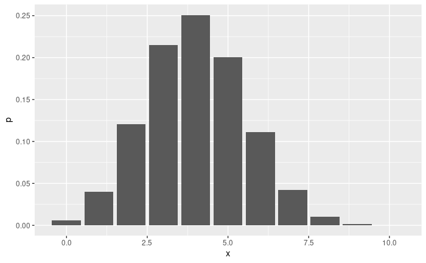

```r
datastuff_polishexercise1 <- data.frame(x=0:10,p=dbinom(x=0:10,size=10,prob=0.4))
ggplot(data=datastuff_polishexercise1,aes(x=x,y=p)) + geom_col()
```

**c.**

```r
dbinom(6,size = 10, prob = 0.4)
```

```
[1] 0.1114767
```

**d.**

```r
pbinom(3,size=10,prob=0.4) # How likely are you to score at most 3 goals?
```

```
[1] 0.3822806
```

### Zadanie 2.

Strzelec oddaje 5 strza l´ow do tarczy. Prawdopodobie´nstwo trafienia w pojedynczym strzale wynosi 0,8. Niech zmienna losowa X przyjmuje warto´sci r´owne liczbie celnych strza l´ow. (a) Znajd´z rozk lad zmiennej losowej X. (b) Sporz ,ad´z wykres rozk ladu prawdopodobie´nstwa zmiennej losowej X. (c) Oblicz prawdopodobie´nstwo, ˙ze strzelec trafi dok ladnie 4 razy w tarcz ,e. (d) Oblicz prawdopodobie´nstwo, ˙ze strzelec trafi w tarcz ,e co najwy˙zej 3 razy. (e) Oblicz prawdopodobie´nstwo, ˙ze strzelec trafi w tarcz ,e co najmniej 2 razy

**a.**

```r
attempts = 5
p = 0.8
datastuff_polishexercise2 <- data.frame(x=0:attempts,p=dbinom(x=0:attempts,size=attempts,prob=p))
datastuff_polishexercise2
```

| x | p |
| --- | --- |
| 0 | 0.00032 |
| 1 | 0.00640 |
| 2 | 0.05120 |
| 3 | 0.20480 |
| 4 | 0.40960 |
| 5 | 0.32768 |

**b.**

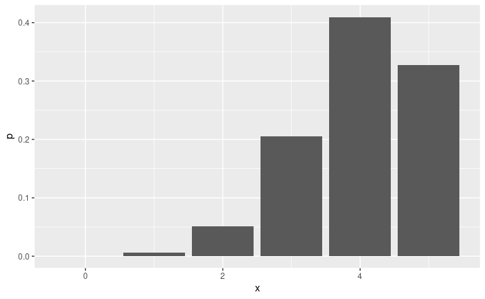

```r
ggplot(data=datastuff_polishexercise2,aes(x=x,y=p)) + geom_col()
```

**c.**

```r
dbinom(4,size=5,prob=0.8) # How likely are you to hit exactly 4 darts?
```

```
[1] 0.4096
```

**d.**

```r
pbinom(3,size=5,prob=0.8) # How likely are you to hit at most 3 darts?
```

```
[1] 0.26272
```

**e.**

```r
1 - pbinom((2-1),size=5,prob=0.8) # How likely are you to hit at least 2 darts?
```

```
[1] 0.99328
```

```r
# there's a (2-1) in there, so that i remember that the "q" value should be 1 less than in the question
```

### Zadanie 3.

Rodzina pragnie mie´c 3 dzieci. Zak ladaj ,ac niezale˙zno´s´c zdarze´n oraz przyjmuj ,ac, ˙ze prawdopodobie´nstwo urodzenia si,e dziewczynki wynosi 0,483 wyznacz rozk lad prawdopodobie´nstwazmiennej losowej zdefiniowanej jako liczba ch lopc´ow w´sr´od 3 urodzonych w tej rodzinie dzieci. Oblicz warto´s´c oczekiwan ,a oraz wariancj,e tej zmiennej losowej.

```r
attempts = 3 # How many children are there going to be?
girl_p = 0.483 # How likely is it that the child will be a girl?
boy_p = 1 - girl_p # How likely is it that the child will be a boy?

# Distribution
children_dist <- data.frame(x=0:attempts,p=dbinom(x=0:attempts,size=attempts,prob=boy_p))
children_dist
```

| x | p |
| --- | --- |
| 0 | 0.1126786 |
| 1 | 0.3618312 |
| 2 | 0.3873018 |
| 3 | 0.1381884 |

```r
# Expected value E(X)
weighted.mean(children_dist$x, children_dist$p)
```

```
[1] 1.551
```

```r
# Variance Var(X)
attempts * girl_p * boy_p #n * p * q
```

```
[1] 0.749133
```

### Zadanie 4.

Za l´o˙zmy, ˙ze pewna zmienna losowa X ma rozk lad dwumianowy z prawdopodobie´nstwem sukcesu p = 0.6. Sporz ,ad´z wykres rozk ladu prawdopodobie´nstwazmiennej losowej X w zale˙zno´sci od liczby do´swiadcze´n n. Przyjmij nast,epuj ,ace warto´sci: n = 5, 10, 15, 20.

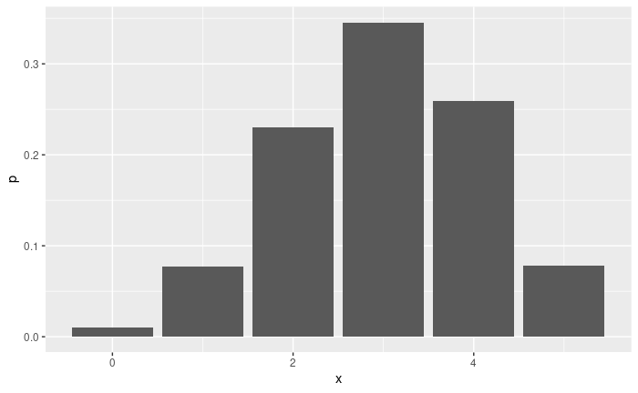

```r
probability = 0.6

# This doesn't work for some reason.
for(i in c(5,10,15,20)) {
  d <- data.frame(x=0:i,p=dbinom(x=0:i,size=i,prob=probability))
  ggplot(data=d,aes(x=x,y=p)) + geom_col()
}

# Do it manually instead. :(
d1 <- data.frame(x=0:5,p=dbinom(x=0:5,size=5,prob=probability))
ggplot(data=d1,aes(x=x,y=p)) + geom_col()
```

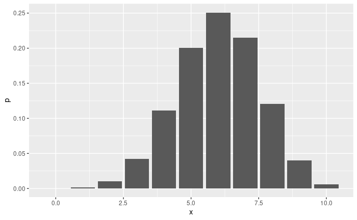

```r
d2 <- data.frame(x=0:10,p=dbinom(x=0:10,size=10,prob=probability))
ggplot(data=d2,aes(x=x,y=p)) + geom_col()
```

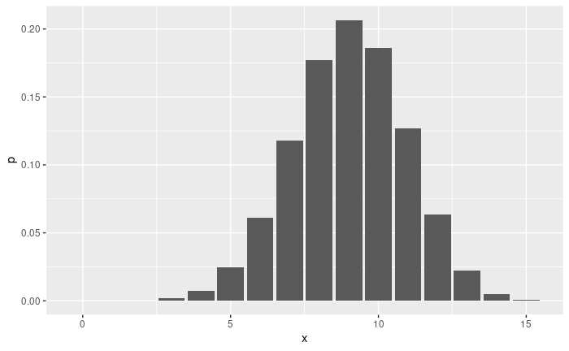

```r
d3 <- data.frame(x=0:15,p=dbinom(x=0:15,size=15,prob=probability))
ggplot(data=d3,aes(x=x,y=p)) + geom_col()
```

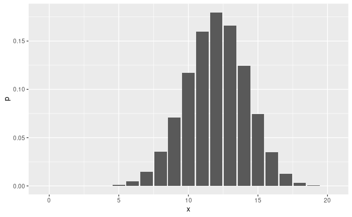

```r
d4 <- data.frame(x=0:20,p=dbinom(x=0:20,size=20,prob=probability))
ggplot(data=d4,aes(x=x,y=p)) + geom_col()
```